# Chapter 4. Multivariate Data

### 4.2.4 Applying functions to a data frame or list

Just use **apply()**

```r
df <- ewr[,3:10]

# data frame, direction(1 = row-wise, 2=colum-wise), function
apply(df, 2, mean)

apply(df, 2, median)
```

**AA**

17.8347826086957

**CO**

20.0195652173913

**DL**

16.6304347826087

**HP**

19.604347826087

**NW**

15.7978260869565

**TW**

16.2804347826087

**UA**

17.6913043478261

**US**

15.4934782608696

**AA**

16.05

**CO**

18.15

**DL**

15.5

**HP**

18.95

**NW**

14.55

**TW**

15.65

**UA**

16.45

**US**

14.45

lapply() : return a list

sapply() : simplify the results into a vector or matrix when appropriate

```r
lapply(df, median)
str(lapply(df, median)) # A list
```

**$AA**

16.05

**$CO**

18.15

**$DL**

15.5

**$HP**

18.95

**$NW**

14.55

**$TW**

15.65

**$UA**

16.45

**$US**

14.45

```
List of 8
 $ AA: num 16.1
 $ CO: num 18.1
 $ DL: num 15.5
 $ HP: num 18.9
 $ NW: num 14.6
 $ TW: num 15.6
 $ UA: num 16.4
 $ US: num 14.4
```

```r
sapply(df, mean)
str(sapply(df, mean)) # A vector
```

**AA**

17.8347826086957

**CO**

20.0195652173913

**DL**

16.6304347826087

**HP**

19.604347826087

**NW**

15.7978260869565

**TW**

16.2804347826087

**UA**

17.6913043478261

**US**

15.4934782608696

```
 Named num [1:8] 17.8 20 16.6 19.6 15.8 ...
 - attr(*, "names")= chr [1:8] "AA" "CO" "DL" "HP" ...
```

## 4.3 Using model formula with multivariate data

### 4.3.1 Boxplots from a model formula

We wouldn't want to specify the data with commands like *gestation[inc==1]*

Just use the model formula, *gestation~inc()* with boxplot().

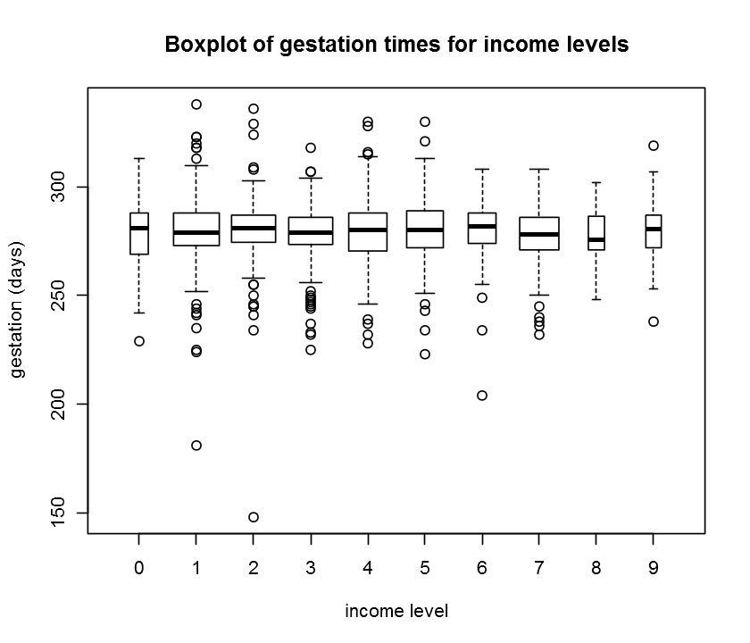

```r
options(repr.plot.height = 6)

boxplot(gestation ~ inc, subset= gestation != 999 & inc != 98,
        data=babies,varwidth=TRUE, xlab="income level", ylab="gestation (days)",
       main = "Boxplot of gestation times for income levels")
```

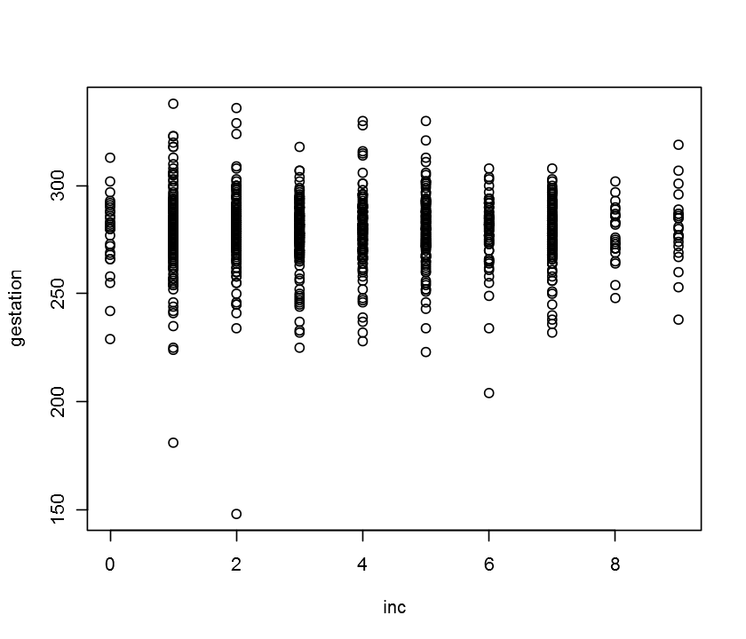

```r
# Scatterplot, numeric~numeric
plot(gestation ~ inc, subset= gestation != 999 & inc != 98,
        data=babies)
```

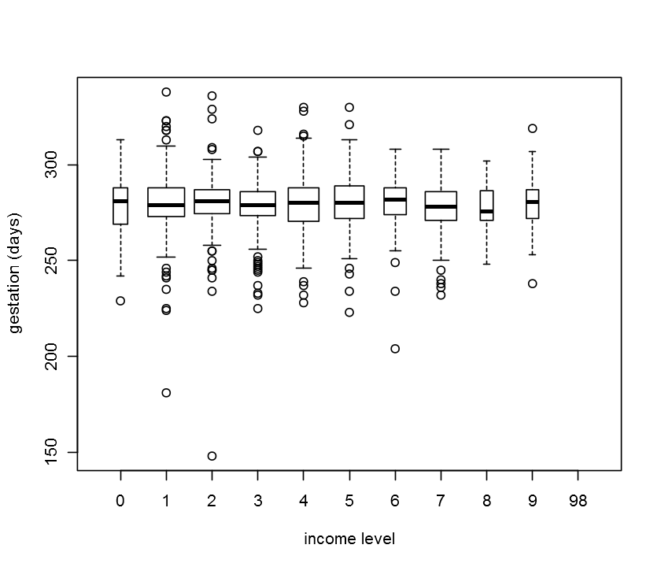

```r
# Boxplot, numeric~factor
plot(gestation ~ factor(inc), data=babies,
varwidth=TRUE, subset = gestation != 999 & inc !=98, xlab="income level", ylab="gestation (days)")
```

### 4.3.3 Creating contingency tables with xtabs()

If we have the count data, not the raw data, we can enter the data in as a data frame and then use **xtabs()** to create contingency tables.

**as.data.frame()** inverts what xtabs() and table() do.

```r
percents <- c(71, 70, 79, 82, 71, 83, 71, 50, 70, 71, 55, 73)
car <- rep(c("passenger", "pickup", "van/suv"),4)
year <- rep(rep(2001:2002, c(3,3)),2)
enforcement <- rep(c("primary", "secondary"),c(6,6))
seatbelts <- data.frame(percents, car, year, enforcement)
seatbelts
```

| percents | car | year | enforcement |
| --- | --- | --- | --- |
| 71 | passenger | 2001 | primary |
| 70 | pickup | 2001 | primary |
| 79 | van/suv | 2001 | primary |
| 82 | passenger | 2002 | primary |
| 71 | pickup | 2002 | primary |
| 83 | van/suv | 2002 | primary |
| 71 | passenger | 2001 | secondary |
| 50 | pickup | 2001 | secondary |
| 70 | van/suv | 2001 | secondary |
| 71 | passenger | 2002 | secondary |
| 55 | pickup | 2002 | secondary |
| 73 | van/suv | 2002 | secondary |

```r
# xtabs() creates contingency tables using a model-formula interface.
# first two components to make a table, the third component to break up the tables

tab <- xtabs(percents~car+year+enforcement, data=seatbelts)
tab
```

```
, , enforcement = primary

           year
car         2001 2002
  passenger   71   82
  pickup      70   71
  van/suv     79   83

, , enforcement = secondary

           year
car         2001 2002
  passenger   71   71
  pickup      50   55
  van/suv     70   73
```

```r
# ftable() flattens the contingency table
ftable(tab, col.vars = c("enforcement", "year"))
```

```
          enforcement primary      secondary
          year           2001 2002      2001 2002
car
passenger                  71   82        71   71
pickup                     70   71        50   55
van/suv                    79   83        70   73
```

### 4.3.4 Manipulating data frames: split() and stack()

**split()**: split up a variable by the levels of some factor.

e.g) boxplot(split(x,f)) produces the same results as boxplot(x~f)

**tapply(x,f,function)** will do the same thing.

**stack()** is inverse to split(). It takes a collection of variables stored in a data frame or list and stacks them into two variables. One contains the values, and the other indicates which variable the data originally came from

```r
cancer
```

**$stomach**

1. 124

2. 42

3. 25

4. 45

5. 412

6. 51

7. 1112

8. 46

9. 103

10. 876

11. 146

12. 340

13. 396

**$bronchus**

1. 81

2. 461

3. 20

4. 450

5. 246

6. 166

7. 63

8. 64

9. 155

10. 859

11. 151

12. 166

13. 37

14. 223

15. 138

16. 72

17. 245

**$colon**

1. 248

2. 377

3. 189

4. 1843

5. 180

6. 537

7. 519

8. 455

9. 406

10. 365

11. 942

12. 776

13. 372

14. 163

15. 101

16. 20

17. 283

**$ovary**

1. 1234

2. 89

3. 201

4. 356

5. 2970

6. 456

**$breast**

1. 1235

2. 24

3. 1581

4. 1166

5. 40

6. 727

7. 3808

8. 791

9. 1804

10. 3460

11. 719

```r
# When  we  use  stack(),  it  is  important  that  the
# variables in the data frame or list have names,
# so that ind can indicate which variable the data is from.

stack(cancer)
```

| values | ind |
| --- | --- |
| 124 | stomach |
| 42 | stomach |
| 25 | stomach |
| 45 | stomach |
| 412 | stomach |
| 51 | stomach |
| 1112 | stomach |
| 46 | stomach |
| 103 | stomach |
| 876 | stomach |
| 146 | stomach |
| 340 | stomach |
| 396 | stomach |
| 81 | bronchus |
| 461 | bronchus |
| 20 | bronchus |
| 450 | bronchus |
| 246 | bronchus |
| 166 | bronchus |
| 63 | bronchus |
| 64 | bronchus |
| 155 | bronchus |
| 859 | bronchus |
| 151 | bronchus |
| 166 | bronchus |
| 37 | bronchus |
| 223 | bronchus |
| 138 | bronchus |
| 72 | bronchus |
| 245 | bronchus |
| ... | ... |
| 180 | colon |
| 537 | colon |
| 519 | colon |
| 455 | colon |
| 406 | colon |
| 365 | colon |
| 942 | colon |
| 776 | colon |
| 372 | colon |
| 163 | colon |
| 101 | colon |
| 20 | colon |
| 283 | colon |
| 1234 | ovary |
| 89 | ovary |
| 201 | ovary |
| 356 | ovary |
| 2970 | ovary |
| 456 | ovary |
| 1235 | breast |
| 24 | breast |
| 1581 | breast |
| 1166 | breast |
| 40 | breast |
| 727 | breast |
| 3808 | breast |
| 791 | breast |
| 1804 | breast |
| 3460 | breast |
| 719 | breast |

## 4.4 Lattice graphics

The basic idea is that the graphic consists of a number of panels. Each panel corresponds to some value(s) of a conditioning variable. The lattice graphing functions are called using the model-formula interface. The formulas have the format

**response ~ predictor|condition**

```r
library(lattice)
# trellis.device(bg="white") : No longer available
options(lattice.theme = "col.whitebg")
```

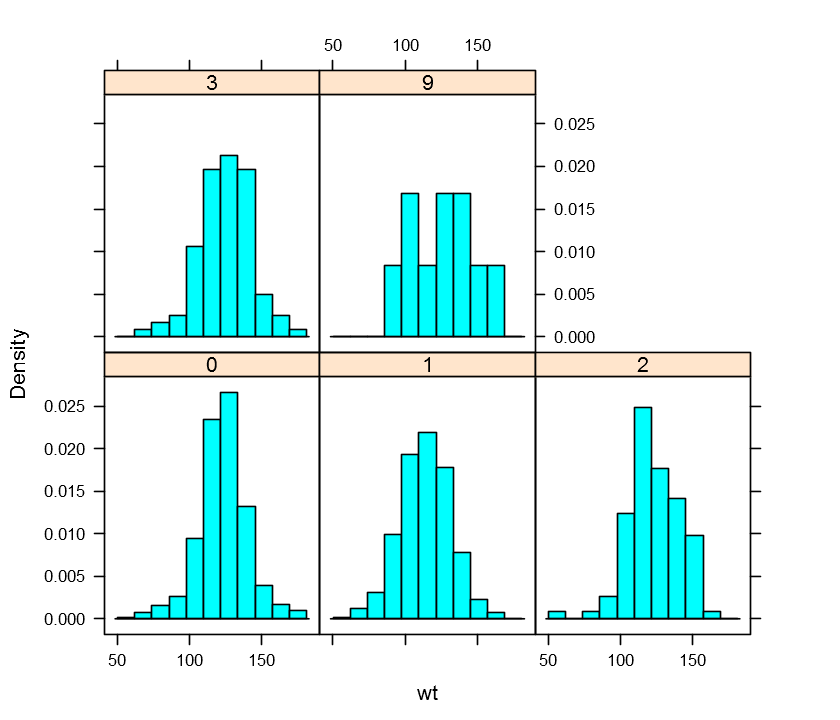

```r
# The argument type="density" makes the total area of the histogram add to 1
# This is the same as prob=TRUE argument in hist()
histogram(~wt|factor(smoke), data=babies, subset = wt!=999, type="density")
```

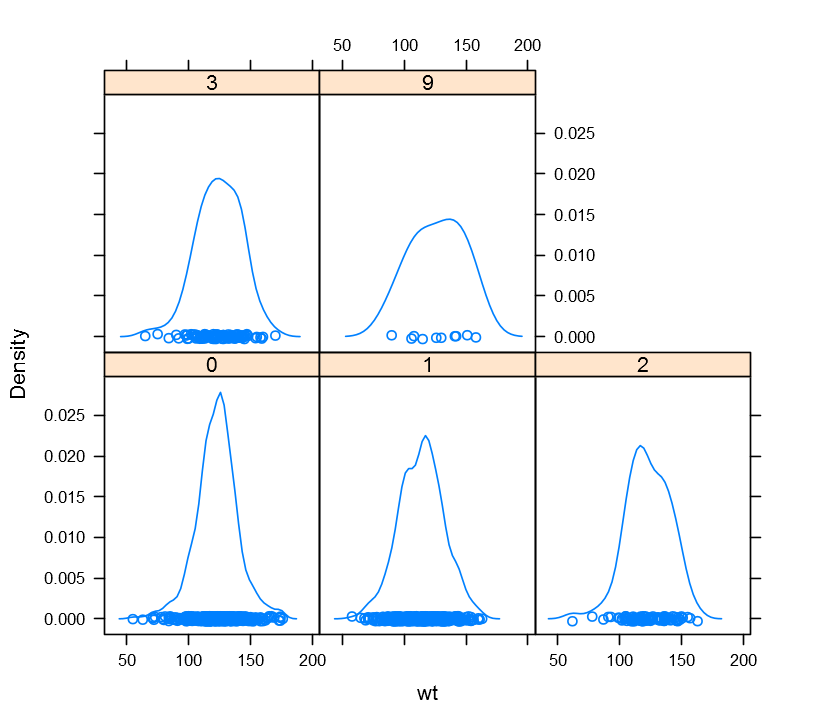

```r
densityplot(~wt|factor(smoke), data=babies)
```

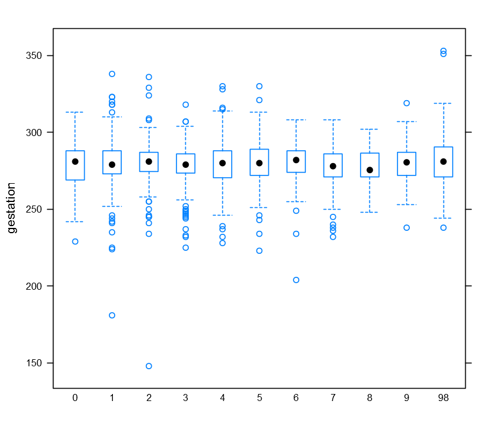

```r
# Boxplots
bwplot(gestation~factor(inc), data=babies, subset=gestation!=999)
```

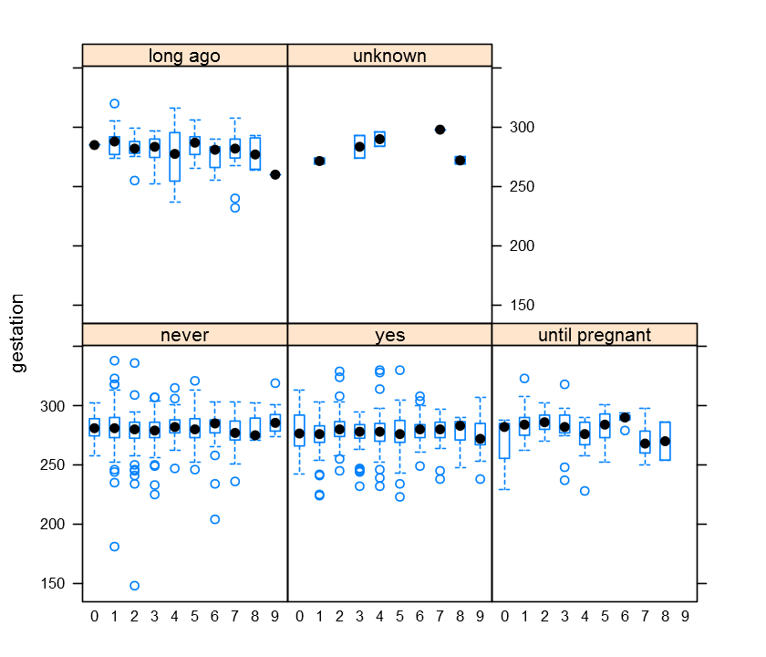

```r
# Break down further by the smoking variable
bwplot(gestation~factor(inc)|factor(smoke, labels=c("never","yes",'until pregnant','long ago','unknown'))
       , data=babies, subset=gestation!=999&inc!=98)
```

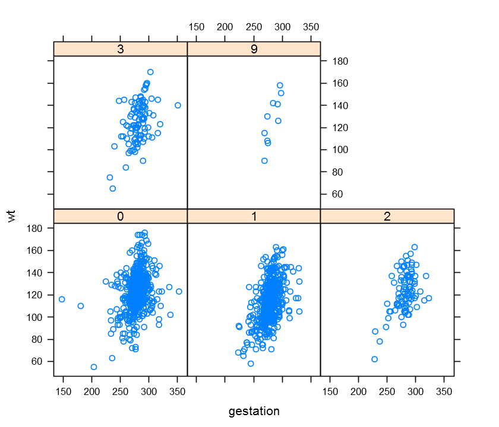

```r
# Scatterplots

xyplot(wt~gestation|factor(smoke), data=babies, subset=(wt!=999&gestation!=999))
```

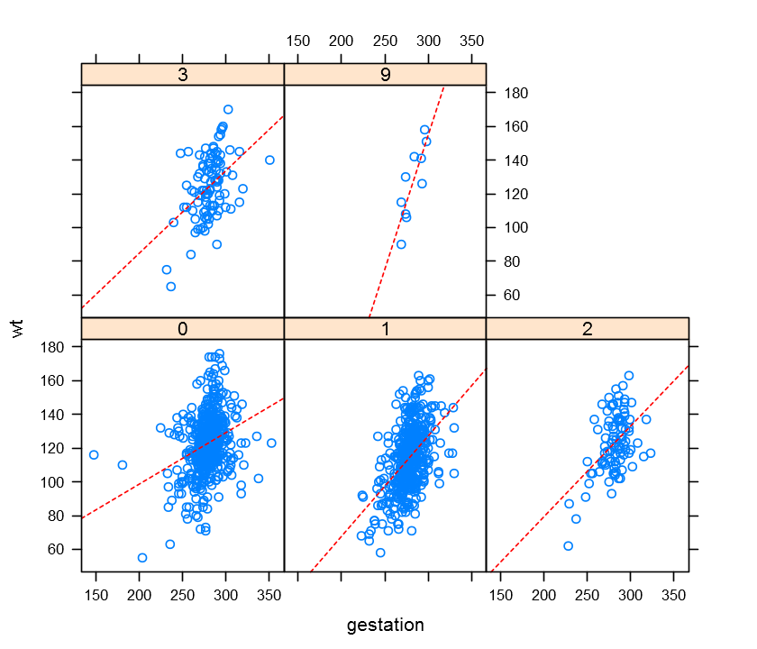

```r
# Scatterplots with regression line

plot.regression <- function(x,y)
    {
    panel.xyplot(x,y)
    panel.abline(lm(y~x), lty=2, col="red")
}

xyplot(wt~gestation | factor(smoke), data=babies,
       subset=(wt != 999 & gestation != 999), panel=plot.regression)
```

## 4.5 Types of data in R

### 4.5.1 Factors

*creating factors*

```r
x <- 1:3;fac<-letters[1:3]
# Levels appear in R console...
factor(x)
factor(fac)

# factors are not numbers
factor(x) + x
```

1. 1

2. 2

3. 3

1. a

2. b

3. c

1. NA

2. NA

3. NA

```r
# adding levels: levels = or levels()
factor(x, levels=1:10)

# The values of data vector being coerced into a factor should match
# those specified to levels.
factor(x, levels=fac)
```

1. 1

2. 2

3. 3

1. NA

2. NA

3. NA

```r
factor(x, levels=1:10)
```

1. 1

2. 2

3. 3

[output not shown]

```r
x <- factor(1:5)
# If you don't specify levels of factors, the levels are set by the values of the
# data vector.
levels(x)

#If you set levels...
x.2 <- factor(1:5, levels=1:10)
# Then the levels of x.2 will be 1, 2, ..., 10
levels(x.2)
```

1. '1'

2. '2'

3. '3'

4. '4'

5. '5'

1. '1'

2. '2'

3. '3'

4. '4'

5. '5'

6. '6'

7. '7'

8. '8'

9. '9'

10. '10'

```r
# setting the levels in the first place by the argument 'levels=' fails
# if the values of data vector being coerced into a factor do not
# match with the values specified as levels
x <- factor(1:3, levels = c("a", "b", "c"))
x
```

1. NA

2. NA

3. NA

```r
# However, first coercing a data vector to a factor,
# THEN setting the values of the level of that factor different from the
# values of the factor could be done with levels()
# However, this will transform the original values of the factor with respect to
# the values of the level defined by a user.
x <- factor(1:3)
# levels are equivalent to the values of the factor, x
levels(x)
# change the levels to c("a", "b", "c")
levels(x) <- letters[1:3]
# the values of the factor, x, are now transformed into "a", "b", and "c",
# so to be alinged with the levels.
x
levels(x)
```

1. '1'

2. '2'

3. '3'

1. a

2. b

3. c

1. 'a'

2. 'b'

3. 'c'

```r
x <- factor(10:12)
x
levels(x) <- c("f", "u", "n")
x
```

1. 10

2. 11

3. 12

1. f

2. u

3. n

```r
# Dropping levels of factors
x <- factor(letters[1:5])
levels(x)


# Releveling with factor(), no levels specified
x <- factor(x[1:3])
levels(x)
```

1. 'a'

2. 'b'

3. 'c'

4. 'd'

5. 'e'

1. 'a'

2. 'b'

3. 'c'

```r
# Use drop=TRUE argument
x <- factor(letters[1:5])
levels(x[1:3, drop=TRUE])
```

1. 'a'

2. 'b'

3. 'c'

```r
l = letters[1:5]
levels(factor(l))

# reverse the order of levels in a factor, using levels=rev() argument
levels(factor(l, levels=rev(l)))
```

1. 'a'

2. 'b'

3. 'c'

4. 'd'

5. 'e'

1. 'e'

2. 'd'

3. 'c'

4. 'b'

5. 'a'

```r
# relevel: If we want a certain level to be considered first!
# ref= argument receives a string, and not a vector of string
# Hence, the command below will have levels in order "d", "a", "b", "c", "e"
levels(relevel(factor(l), ref=c("d")))
```

[output not shown]

```r
# This command will have levels in order "c", "e", "d", "b", "a"
levels(relevel(factor(l, levels=rev(l)), ref=c("c")))
```

1. 'c'

2. 'e'

3. 'd'

4. 'b'

5. 'a'

Read the book, UsingR to study "coercion part"